# Exploratory Data Analysis Answer

Yuwei Cheng

2023-06-12

# Introduction

## Motivation

In this lab, we are going to conduct exploratory data analysis for resale house price in Beijing, China. The data can be downloaded from [this link](https://www.kaggle.com/datasets/ruiqurm/lianjia)

There are several reasons for me to choose this dataset for you to practice. First, this is a raw dataset fetched from an online website. It contains many missing values, corrupted entries, and wrong data type encoding, which serves as a good practice for your data cleaning skills. Second, this dataset has various data type, for example, categorical variables, continuous variables, strings, links, and etc. This requires different data visualization skills. Finally, this is a large dataset that contains rich information and interesting patterns (more than 20 variables and around 300K records).

## Feature Description (data type)

- url: the url which fetches the data(character)
- id: the id of transaction(character)
- Lng: and Lat coordinates, using the BD09 protocol. (numerical)
- Cid: community id (numerical)
- tradeTime: the time of transaction (dates)
- DOM: active days on market. (integer)
- followers: the number of people follow the transaction. (integer)
- totalPrice: the total price (numerical)
- price: the average price by square (numerical)
- square: the square of house (numerical)
- livingRoom: the number of living room (character)
- drawingRoom: the number of drawing room (character)
- kitchen: the number of kitchen (integer)
- bathroom the number of bathroom (integer)
- floor: the height of the house (integer)
- buildingType: including tower (1) , bungalow (2)，combination of plate and tower (3), plate (4) (categorical)
- constructionTime: the time of construction (numerical)
- renovationCondition: including other (1), rough(2),Simplicity (3), hardcover (4) (categorical)
- buildingStructure: including unknown (1), mixed(2), brick and wood (3), brick and concrete (4), steel (5) and steel-concrete composite (6). (categorical)
- ladderRatio: the proportion between number of residents on the same floor and number of elevator of ladder. It describes how many ladders a resident have on average. (numerical)
- elevator have (1) or not have elevator (0) (binary)
- fiveYearsProperty: if the owner have the property for less than 5 years (binary)
- subway: if there is subway nearby (1) else (0) (binary)

# Explorartory Data Analysis

## Data Cleaning

### Install and Load Packages

Below are the libraries which you need for this exercise.

```r
# install.packages("dplyr")
# install.packages("ggplot2")
# install.packages("reshape2")
# install.packages("ggpubr")
# install.packages("ggcorrplot")
library(dplyr)
library(ggplot2)
library(tidyr)
library(lubridate)
library(ggpubr)
library(knitr)
library(ggcorrplot)
```

### Load Data

There are several shortcuts you can use for Rmarkdown

1. **ctl + shift + enter** to run the cell
2. **ctl + alt + i** to insert a new cell
3. **ctl + alt + c** to comment
4. More shortcuts can be found [here](https://bookdown.org/yihui/rmarkdown-cookbook/rstudio-shortcuts.html)

Define your home path and load data from your home path. You can do something similar to the code chuck below

Define your home path and load data from your home path. You can do something similar to the code chuck below

```r
###
home_path <- "D:/UChicago/2-Quarters/2023-8-Summer/biobootcamp/data/"

###
data <- read.csv(paste0(home_path, "house_price.csv"),  # data path
                sep = ",",
                stringsAsFactors = FALSE,
                fileEncoding = "latin1")

# Extract the number of floor as numerical variable
data$floor <- as.numeric(sapply(data$floor, function(x) strsplit(x,' ')[[1]][2]))
```

```r
# shortcut ctl + shift + enter
home_path <- "D:/UChicago/2-Quarters/2023-8-Summer/biobootcamp/data/"
data <- read.csv(paste0(home_path, "house_price.csv"),
                sep = ",",
                stringsAsFactors = FALSE,
                fileEncoding = "latin1")
# extract the number of floor as numerical
data$floor <- as.numeric(sapply(data$floor, function(x) strsplit(x,' ')[[1]][2]))
```

### Generate Data Summary and Answer Questions

```r
dim(data)
```

```
## [1] 318851     26
```

```r
summary(data)
```

```
##      url                 id                 Lng             Lat
##  Length:318851      Length:318851      Min.   :116.1   Min.   :39.63
##  Class :character   Class :character   1st Qu.:116.3   1st Qu.:39.89
##  Mode  :character   Mode  :character   Median :116.4   Median :39.93
##                                        Mean   :116.4   Mean   :39.95
##                                        3rd Qu.:116.5   3rd Qu.:40.00
##                                        Max.   :116.7   Max.   :40.25
##
##       Cid             tradeTime              DOM            followers
##  Min.   :1.111e+12   Length:318851      Min.   :   1.00   Min.   :   0.00
##  1st Qu.:1.111e+12   Class :character   1st Qu.:   1.00   1st Qu.:   0.00
##  Median :1.111e+12   Mode  :character   Median :   6.00   Median :   5.00
##  Mean   :1.129e+12                      Mean   :  28.82   Mean   :  16.73
##  3rd Qu.:1.111e+12                      3rd Qu.:  37.00   3rd Qu.:  18.00
##  Max.   :1.115e+15                      Max.   :1677.00   Max.   :1143.00
##                                         NA's   :157977
##    totalPrice          price            square         livingRoom
##  Min.   :    0.1   Min.   :     1   Min.   :   6.90   Length:318851
##  1st Qu.:  205.0   1st Qu.: 28050   1st Qu.:  57.90   Class :character
##  Median :  294.0   Median : 38737   Median :  74.26   Mode  :character
##  Mean   :  349.0   Mean   : 43530   Mean   :  83.24
##  3rd Qu.:  425.5   3rd Qu.: 53820   3rd Qu.:  98.71
##  Max.   :18130.0   Max.   :156250   Max.   :1745.50
##
##  drawingRoom           kitchen         bathRoom             floor
##  Length:318851      Min.   :0.0000   Length:318851      Min.   : 1.0
##  Class :character   1st Qu.:1.0000   Class :character   1st Qu.: 6.0
##  Mode  :character   Median :1.0000   Mode  :character   Median :11.0
##                     Mean   :0.9946                      Mean   :13.3
##                     3rd Qu.:1.0000                      3rd Qu.:19.0
##                     Max.   :4.0000                      Max.   :63.0
##                                                         NA's   :32
##   buildingType   constructionTime   renovationCondition buildingStructure
##  Min.   :0.048   Length:318851      Min.   :0.000       Min.   :0.000
##  1st Qu.:1.000   Class :character   1st Qu.:1.000       1st Qu.:2.000
##  Median :4.000   Mode  :character   Median :3.000       Median :6.000
##  Mean   :3.010                      Mean   :2.606       Mean   :4.451
##  3rd Qu.:4.000                      3rd Qu.:4.000       3rd Qu.:6.000
##  Max.   :4.000                      Max.   :4.000       Max.   :6.000
##  NA's   :2021
##   ladderRatio          elevator     fiveYearsProperty     subway
##  Min.   :       0   Min.   :0.000   Min.   :0.0000    Min.   :0.0000
##  1st Qu.:       0   1st Qu.:0.000   1st Qu.:0.0000    1st Qu.:0.0000
##  Median :       0   Median :1.000   Median :1.0000    Median :1.0000
##  Mean   :      63   Mean   :0.577   Mean   :0.6456    Mean   :0.6011
##  3rd Qu.:       0   3rd Qu.:1.000   3rd Qu.:1.0000    3rd Qu.:1.0000
##  Max.   :10009400   Max.   :1.000   Max.   :1.0000    Max.   :1.0000
##                     NA's   :32      NA's   :32        NA's   :32
##     district      communityAverage
##  Min.   : 1.000   Min.   : 10847
##  1st Qu.: 6.000   1st Qu.: 46339
##  Median : 7.000   Median : 59015
##  Mean   : 6.764   Mean   : 63682
##  3rd Qu.: 8.000   3rd Qu.: 75950
##  Max.   :13.000   Max.   :183109
##                   NA's   :463
```

#### Q1

How many rows in this dataset? How many columns in this dataset?

**There are 318851 records and 26 columns**.

#### Q2

Which variables contain missing value?

**DOM, floor, buildingType, elevator, fiveYearsProperty, subway, and communityAverage**

### Remove url, id, Cid, DOM from this dataset then Remove Missing Values

```r
data <- data %>% select(-url, -id, -Cid, -DOM) %>% drop_na()
```

### Convert tradeTime from String to Date

You might use **ymd()** function from library(lubridate) to convert string to date format. ymd stands for year-month-date

```r
data$tradeTime <- data$tradeTime %>% ymd()
```

### Create a new variable year

```r
data$year <- sapply(data$tradeTime, year)
```

### Convert livingRoom, drawingRoom, bathRoom, constructionTime from string to numeric

You might use **as.numeric()** function. For example, you might do

```r
data$livingRoom <- as.numeric(data$livingRoom)
data$drawingRoom <- as.numeric(data$drawingRoom)
data$bathRoom <- as.numeric(data$bathRoom)
data$constructionTime <- as.numeric(data$constructionTime)
data <- data %>% drop_na()  # Remove NAs introduced by coercion
```

### Create Function To Add Catergory Labels

In this session, you need to create your own function. You might do something like

1. **makeBuildingType** is the function name
2. **x** is the input of the function
3. This function will return the associated label
4. More detials of R style guide can be found [here](https://jef.works/R-style-guide/)

```r
#' Add category label for the BuildingType variable
#'
#' @param x a building type record
#' @return the associated label for x
#'
#' @examples
#' makeBuildingType(1)
#'
makeBuildingType <- function(x)
{
  if(x==1){return('Tower')}
  else if(x==2){return('Bungalow')}
  else if(x==3){return('Mix_plate_tower')}
  else if(x==4){return('plate')}
}
data$buildingType <- sapply(data$buildingType, makeBuildingType)
data$buildingType <- as.factor(data$buildingType)
```

### Add Cateory Labels for Renovation Condition and Building Structure

```r
makeRenovationCondition <- function(x)
{
  if(x==1){return('Other')}
  else if(x==2){return('Rough')}
  else if(x==3){return('Simplicity')}
  else if(x==4){return('Hardcover')}
}
data$renovationCondition <- sapply(data$renovationCondition, makeRenovationCondition)
data$renovationCondition <- as.factor(data$renovationCondition)


makeBuildingStructure <- function(x)
{
  if(x==1){return('Unknown')}
  else if(x==2){return('Mix')}
  else if(x==3){return('Brick_Wood')}
  else if(x==4){return('Brick_Concrete')}
  else if(x==5){return('Steel')}
  else if(x==6){return('Steel_Concrete')}
}
data$buildingStructure <- sapply(data$buildingStructure, makeBuildingStructure)
data$buildingStructure <- as.factor(data$buildingStructure)
```

### Convert elevator, fiveYearsProperty, subway, district from numeric to categorical variable

```r
data$elevator <- as.factor(data$elevator)
data$fiveYearsProperty <- as.factor(data$fiveYearsProperty)
data$subway <- as.factor(data$subway)
data$district <- as.factor(data$district)
```

### Remove record which contains wrong values

#### Q3 Which record do you think contains wrong value? Remove that record.

Hint: Ladder ratio describe how many ladders a resident have on average. Do you think it is possible for a building to have ladder ratio greater than 10?

```r
data = data[data$ladderRatio < 10, ]
```

#### Q4 How many records and features do you have after data cleaning?

**After cleaning, there are 297699 records and 23 variables**

```r
dim(data)
```

```
## [1] 297699     23
```

## Data Visualization

### Q5 Plot the Average Resale House Price Per Square After 2011 by District with Following Instructions

1. Label the figure title as “Average Resale House Price Per Square By District Over Time”
2. The figure should contain 13 lines with different colors. Each line represents one district.
3. Label y axis as “Average Price”
4. Set y axis limit as (10000, 110000)
5. Question: what is the general trend of the average price per square over time? which district has the highese average price per square?

**The average price per square tend to increase from 2012 to 2017 and decrease from 2017 onwards. District 10 has the highest average price per square**

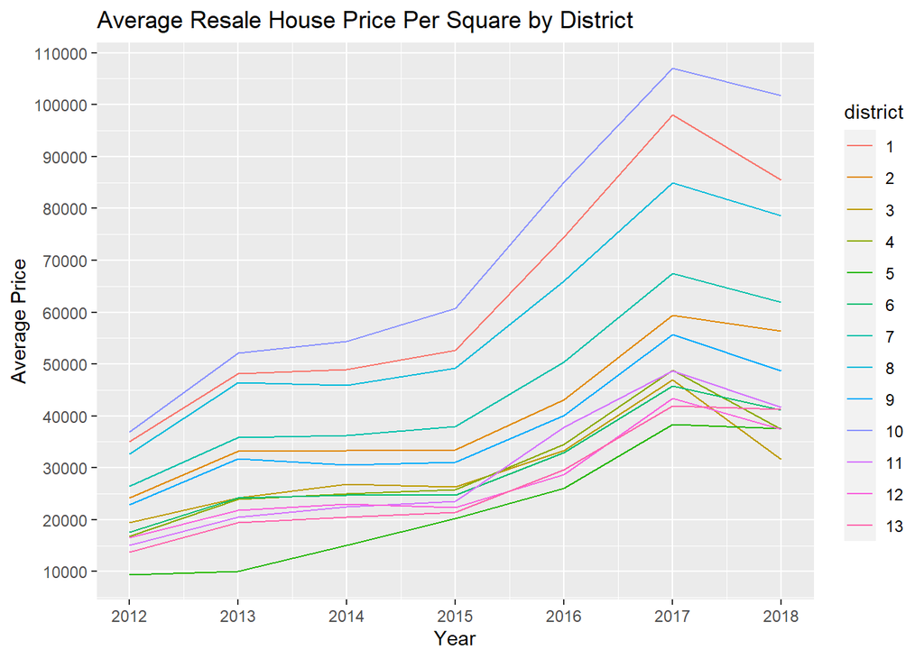

```r
# Compute average price per square by district over time
data %>% subset(year >= 2012) %>%
  group_by(year, district) %>% summarise(ave_price = mean(price)) %>%
  ggplot()+
  geom_line(aes(x = year, y = ave_price, group = district, color = district)) +
  scale_x_continuous(breaks = seq(2012, 2018, 1)) +
  scale_y_continuous(breaks = seq(10000, 110000, 10000)) +
  labs(title = "Average Resale House Price Per Square by District",
       x = "Year", y = "Average Price")
```

**fig.width=18, fig.height=8** sets the figure display format. More R code chunk options can be found [here](https://rmarkdown.rstudio.com/lesson-3.html)

### Q6 Plot the Geographic Information by District with Following Instructions

1. Set Lng as x axis, Lat as y axis
2. Label the figure title as “Geographic Distribution by District”
3. Question: do you think geographic location is related to the average resale house price?

**Yes, center of the city tends to have the higher average price, for example, district 10 and 1**

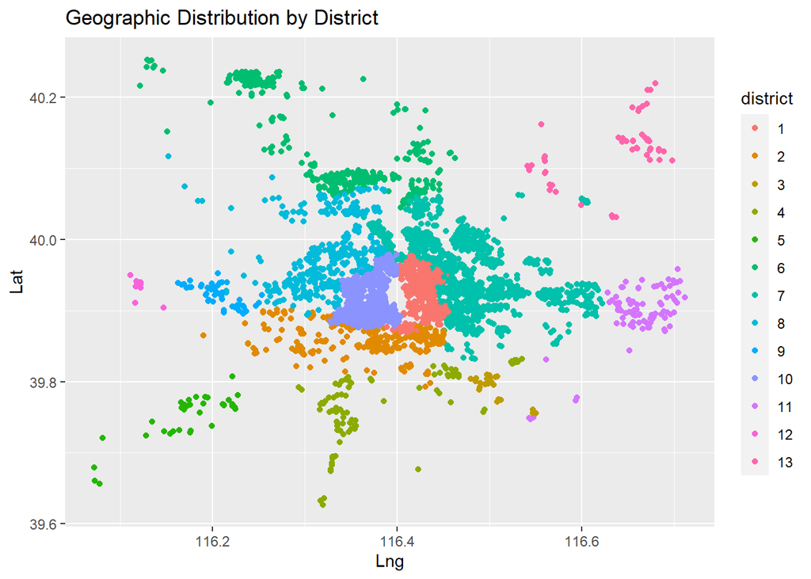

```r
data %>%
  ggplot() +
  geom_point(aes(x = Lng, y =Lat, group = district, color = district)) +
  labs(title = "Geographic Distribution by District")
```

### Q7 Plot the Average Followers Over Time By District with Following Instructions

1. Label the figure title as “Average Followers By District Over Time”
2. The figure should contain 13 lines with different colors. Each line represents one district.
3. Label x axis as “Year” and label y axis as “Average Followers”
4. Question: Which district has increasing attention for recent years (increasing followers) and why? Hint: you may answer this question based on the information from the previous two plots

**Followers of District 3 has increased rapidly for recent year, since it has the lowest average price and it is not too far from the center of the city**

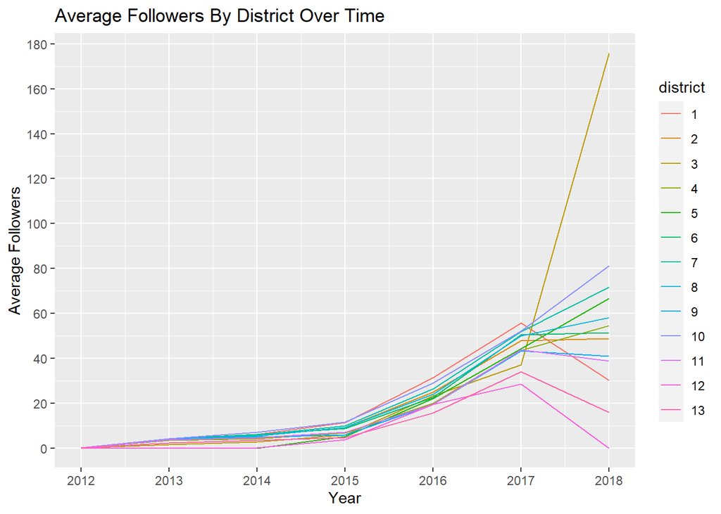

```r
data %>% subset(year >= 2012) %>%
  group_by(year, district) %>% summarise(ave_price = mean(followers)) %>%
  ggplot()+
  geom_line(aes(x = year, y = ave_price, group = district, color = district)) +
  scale_x_continuous(breaks = seq(2012, 2018, 1)) +
  scale_y_continuous(breaks = seq(0, 180, 20)) +
  labs(title = "Average Followers By District Over Time",
       x = "Year", y = "Average Followers")
```

### Q8 Use Boxplot to Demonstrate Price Quantiles of buildingType, buildingStructure, and renovationCondition with Following Instructions

1. Put three figures into one row.
2. Question: which buildingType tends to have higher average price? Answer the same question for buildingStructure and renovationCondition.

**Bunglow, Brick_Wood, and Hardcover tend to have higher average price**

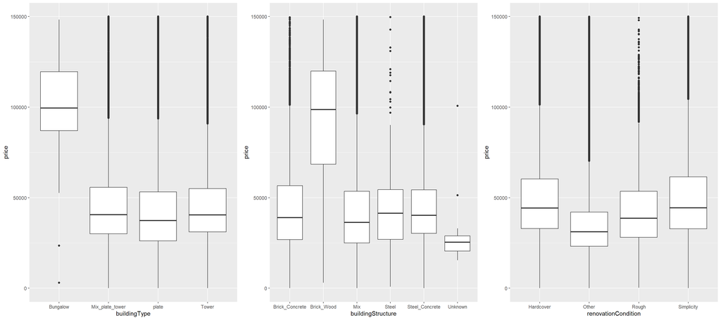

```r
p1 = data %>%
  ggplot(aes(x = buildingType, y = price)) +
  geom_boxplot()

p2 = data %>%
  ggplot(aes(x = buildingStructure, y = price)) +
  geom_boxplot()

p3 = data %>%
  ggplot(aes(x = renovationCondition, y = price)) +
  geom_boxplot()

ggarrange(p1, p2, p3, nrow = 1)
```

### Q9 Create Density Plot of House Square by Building Type with Following Instructions

**Bungalow**

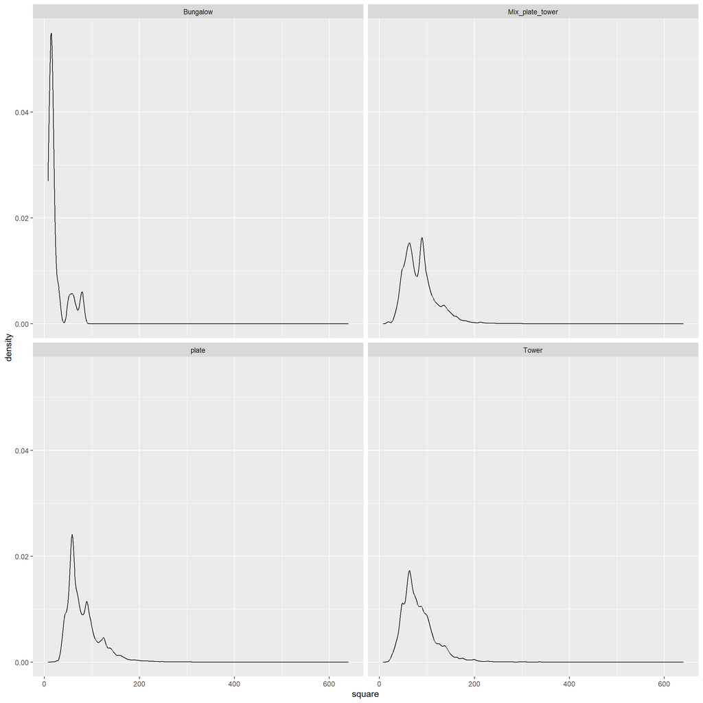

```r
data %>%
  ggplot() +
  geom_density(aes(x = square)) +
  facet_wrap(~buildingType)
```

### Q10 On average, how much more (less) you need to pay price per square for house with subway nearby than house without subway? Answer the same question for elevator, and fiveYearsProperty

```r
data %>% group_by(elevator) %>% summarise(ave_price = mean(price)) %>% select(ave_price)
```

```
## # A tibble: 2 × 1
##   ave_price
##       <dbl>
## 1    42480.
## 2    44829.
```

```r
data %>% group_by(subway) %>% summarise(ave_price = mean(price)) %>% select(ave_price)
```

```
## # A tibble: 2 × 1
##   ave_price
##       <dbl>
## 1    37646.
## 2    47902.
```

```r
data %>% group_by(fiveYearsProperty) %>% summarise(ave_price = mean(price)) %>% select(ave_price)
```

```
## # A tibble: 2 × 1
##   ave_price
##       <dbl>
## 1    43611.
## 2    43932.
```

### Q11 Display the Top 5 House Construction Time with Associated Counts

```r
data %>% group_by(constructionTime) %>%
  summarise(count=n()) %>% arrange(-count) %>%
  head(5) %>% kable()
```

| constructionTime | count |
| --- | --- |
| 2004 | 21003 |
| 2003 | 19252 |
| 2005 | 18734 |
| 2006 | 14739 |
| 2007 | 14126 |

### Q12 Create Correlation Plot for All Numerical Variables in this Dataset

1. What are the top three most correlated (negative / positive) variables

**Bathroom and square, living room and square, community average and price per square**

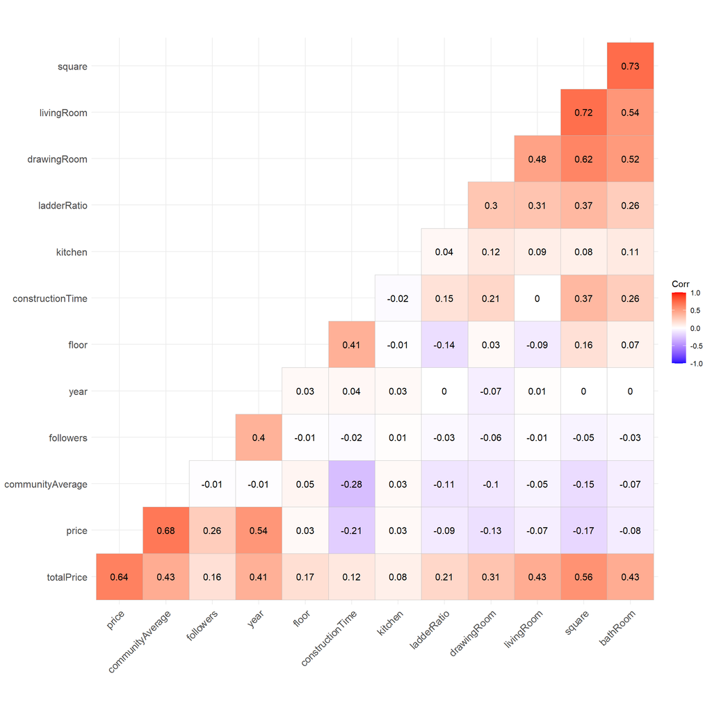

```r
ggcorrplot(cor(data %>% select_if(is.numeric) %>% select(-Lng, -Lat),
               use ="pairwise.complete.obs",method='pearson'),
           hc.order = TRUE,
           type = "lower",
           lab = TRUE)
```

## Summary

### Q13 From the above analysis, which variables do you think can be used to explain the resale house price?

**location (district), year (time), followers (demand), facility (subway, elevator)…**